# Sensitivity analyses: settings, figures and tables

Published

November 20, 2026

**.**

```r
library(dplyr)
library(tidyr)
library(ggplot2)
library(knitr)

# root of the simulation repository, relative to this file
repo <- normalizePath("/home/rstudio/mac/IMR/article/imr-reproducible-code")
read_results <- function(part) {
  readRDS(file.path(repo, "output/sensitivity",
                    paste0("results_", part, ".rds")))
}

# Run a results script of code/sensitivity/ from the root of the simulation
# repository, in an environment of its own. Returns that environment: the
# objects of the script, and its figures in `figures`, named after their
# files. The script writes nothing and its printed tables are dropped.
run_script <- function(file) {
  withr::local_options(list(width = getOption("width")))
  env <- new.env(parent = globalenv())
  env$figures <- list()
  env$ggsave <- function(filename, plot, ...) {
    env$figures[[sub("\\.pdf$", "", basename(filename))]] <- plot
  }
  env$dir.create <- function(...) invisible(FALSE)
  env$commandArgs <- function(...) character(0)   # the full-size results
  withr::with_dir(repo, utils::capture.output(
    sys.source(file.path("code/sensitivity", file), envir = env)
  ))
  return(env)
}

miss <- run_script("missingness_results.R")
ident <- run_script("identification_results.R")
sparse <- run_script("identification_sparse_results.R")
old <- run_script("4_plots.R")   # initialization and sources of variability

# RSSthemes draws the text of the figures with showtext, which assumes 96 dpi
# on a bitmap device: give it the resolution of the figures of this document.
#showtext::showtext_opts(
#  dpi = opts_chunk$get("dpi") * opts_chunk$get("fig.retina")
#)

# "mean (standard deviation)" of a column, as text
mean_sd <- function(x, digits = 4) {
  return(sprintf("%.*f (%.*f)", digits, mean(x), digits, sd(x)))
}

# the cell of a scenario of the identification runs, as a label
cell_label <- function(scenario, level) {
  return(if_else(scenario == "Noise", paste("SNR", level),
                 paste0(level, "% missing")))
}
```

# 1 general setting

- **Model**
  - $\Theta^\star=X\beta^\star+\Gamma^\star Z^\top+M^\star$, $M^\star=AB^\top$,
  - $Y_{ij}=\Theta^\star_{ij}+\varepsilon_{ij}$
  - $\varepsilon_{ij}\sim N(0,\sigma^2)$ and $\sigma=\operatorname{sd}(\Theta^\star)/\mathrm{SNR}$.
  - $m=600$, $p=q=3$, $r=4$.
- **Identification Conditions**: (C1) $X^\top M=0$, (C2) $MZ=0$, (C3) $X^\top\Gamma=0$.
  - $T(\Theta)$ is the decomposition of $\Theta$ that satisfies them.
- **Estimates**:
  - $\hat\beta$, $\hat\Gamma$ are returned by the algorithm;
  - $\tilde\beta$, $\tilde\Gamma$ identified estimates using $\hat\Theta$.
- **Error**: $\mathrm{RRMSE}=\|\text{estimate}-\text{target}\|_F/\|\text{target}\|_F$.
- Rank is given. thresh = $1e-6$ , maxit = $2000$, $scale=TRUE$, $center=FALSE$,
- $\lambda_m$ is tuned for all.

|  | Missingness | Identified, dense | Identified, sparse | Initialization |
| --- | --- | --- | --- | --- |
| $n$ | 200 to 1000 | 600 | 600 | 600 |
| Missing | 70% | 30%; 10% to 90% | 30%; 10% to 90% | 70% |
| SNR | 3 | 0.5 to 10; 3 | 0.5 to 10; 3 | 3 |
| Mechanism | MCAR, MAR(X), MAR(XZ) | MCAR | MCAR | MCAR |
| $X$, $Z$ | centered | centered | centered | not centered |
| Truth | (C1)–(C3) hold | both versions | don’t hold, half coefficients zeros | don’t hold |
| Rank | fixed at 4 | fixed at 4 | fixed at 4 | tuned |
| $\lambda_\beta$, $\lambda_\Gamma$ | 0 | 0 | tuned | 0 |
| $\lambda_M$ path | slow | fast | fast | fast |

# 2 Missingness mechanism

- One dataset $1000\times600$ per replication and (C1)–(C3) hold; the fits use its first $n\in\{200,400,600,800,1000\}$ rows.
- Seven masks from the same uniforms, with mean observation rate 0.3:
  - $\operatorname{logit}\pi_{ij}=\alpha_0+\kappa_xs_i+\kappa_zt_j$,
  - where $s_i$ and $t_j$ are the standardized $X$ and $Z$ times random unit vectors.
  - MCAR: $\kappa_x=\kappa_z=0$.
  - MAR(X): $\kappa_x\in\{0.5,0.75,1\}$, $\kappa_z=0$.
  - MAR(XZ): $\kappa_x=\kappa_z\in\{0.25,0.5,0.75\}$.
- 1000 replications $\times$ 7 mechanisms $\times$ 5 sizes. The number in the name is $\pi_{\max}/\pi_{\min}$.

## 2.1 Tables

**Mechanisms**

**.**

```r
miss$mechanisms %>%
  transmute(
    Mechanism = mechanism, `$\\kappa_x$` = kappa_x, `$\\kappa_z$` = kappa_z,
    `$\\pi_{\\max}/\\pi_{\\min}$` = pi_ratio,
    `Observed rate` = sprintf("%.3f", obs_rate),
    `Fewest in a row` = fewest_in_a_row,
    `Fewest in a column` = fewest_in_a_column, Replications = 1000
  ) %>%
  kable(digits = c(0, 2, 2, 1, 0, 0, 0, 0), align = "lrrrrrrr")
```

Table 1

| Mechanism | $\kappa_x$ | $\kappa_z$ | $\pi_{\max}/\pi_{\min}$ | Observed rate | Fewest in a row | Fewest in a column | Replications |
| --- | --- | --- | --- | --- | --- | --- | --- |
| MCAR | 0.00 | 0.00 | 1.0 | 0.300 | 128 | 33 | 1000 |
| MAR X (5) | 0.50 | 0.00 | 5.2 | 0.300 | 38 | 32 | 1000 |
| MAR X (12) | 0.75 | 0.00 | 11.5 | 0.300 | 17 | 33 | 1000 |
| MAR X (25) | 1.00 | 0.00 | 25.1 | 0.300 | 5 | 31 | 1000 |
| MAR XZ (5) | 0.25 | 0.25 | 5.1 | 0.300 | 83 | 20 | 1000 |
| MAR XZ (23) | 0.50 | 0.50 | 22.8 | 0.300 | 38 | 8 | 1000 |
| MAR XZ (93) | 0.75 | 0.75 | 92.9 | 0.300 | 20 | 4 | 1000 |

**\(\hat\Theta\), unobserved entries**

**.**

```r
# Error by mechanism and n: mean (standard deviation) over the replications,
# then the change of the mean from MCAR at the same n, in %. Every
# replication has its seven mechanisms, so this change is the mean paired
# difference over the MCAR mean.
miss_table <- function(error) {
  miss$rows %>%
    group_by(mechanism, n) %>%
    summarise(mean = mean(.data[[error]]), cell = mean_sd(.data[[error]]),
              .groups = "drop") %>%
    group_by(n) %>%
    mutate(
      change = 100 * (mean / mean[mechanism == "MCAR"] - 1),
      cell = if_else(mechanism == "MCAR", cell,
                     sprintf("%s (%+.1f%%)", cell, change))
    ) %>%
    ungroup() %>%
    select(Mechanism = mechanism, n, cell) %>%
    pivot_wider(names_from = n, values_from = cell, names_glue = "$n={n}$")
}
kable(miss_table("theta_unobs_full"))
```

Table 2: RRMSE of unobserved (test) $\hat\Theta$, mean (sd), (change of the mean from MCAR).

| Mechanism | $n=200$ | $n=400$ | $n=600$ | $n=800$ | $n=1000$ |
| --- | --- | --- | --- | --- | --- |
| MCAR | 0.1434 (0.0023) | 0.1094 (0.0013) | 0.0967 (0.0009) | 0.0901 (0.0007) | 0.0859 (0.0006) |
| MAR X (5) | 0.1468 (0.0032) (+2.4%) | 0.1137 (0.0016) (+3.9%) | 0.1016 (0.0011) (+5.0%) | 0.0953 (0.0009) (+5.8%) | 0.0913 (0.0007) (+6.3%) |
| MAR X (12) | 0.1529 (0.0043) (+6.6%) | 0.1207 (0.0023) (+10.3%) | 0.1092 (0.0017) (+12.9%) | 0.1033 (0.0014) (+14.6%) | 0.0995 (0.0012) (+15.9%) |
| MAR X (25) | 0.1653 (0.0066) (+15.3%) | 0.1352 (0.0044) (+23.6%) | 0.1246 (0.0036) (+28.8%) | 0.1192 (0.0033) (+32.3%) | 0.1158 (0.0031) (+34.9%) |
| MAR XZ (5) | 0.1471 (0.0027) (+2.6%) | 0.1119 (0.0014) (+2.3%) | 0.0989 (0.0010) (+2.3%) | 0.0921 (0.0008) (+2.3%) | 0.0878 (0.0007) (+2.3%) |
| MAR XZ (23) | 0.1585 (0.0039) (+10.6%) | 0.1192 (0.0019) (+9.0%) | 0.1052 (0.0012) (+8.8%) | 0.0979 (0.0010) (+8.7%) | 0.0933 (0.0008) (+8.6%) |
| MAR XZ (93) | 0.1792 (0.0069) (+25.0%) | 0.1310 (0.0027) (+19.7%) | 0.1150 (0.0017) (+18.9%) | 0.1069 (0.0014) (+18.7%) | 0.1019 (0.0011) (+18.7%) |

**\(\hat\beta\)**

**.**

```r
kable(miss_table("beta_raw"))
```

| Mechanism | $n=200$ | $n=400$ | $n=600$ | $n=800$ | $n=1000$ |
| --- | --- | --- | --- | --- | --- |
| MCAR | 0.2291 (0.0294) | 0.1497 (0.0185) | 0.1131 (0.0132) | 0.0893 (0.0090) | 0.0718 (0.0064) |
| MAR X (5) | 0.2288 (0.0294) (-0.1%) | 0.1495 (0.0187) (-0.1%) | 0.1130 (0.0132) (-0.1%) | 0.0891 (0.0090) (-0.2%) | 0.0717 (0.0064) (-0.2%) |
| MAR X (12) | 0.2287 (0.0296) (-0.1%) | 0.1494 (0.0186) (-0.2%) | 0.1130 (0.0132) (-0.2%) | 0.0890 (0.0091) (-0.4%) | 0.0716 (0.0064) (-0.3%) |
| MAR X (25) | 0.2290 (0.0299) (-0.0%) | 0.1496 (0.0187) (-0.1%) | 0.1131 (0.0135) (-0.0%) | 0.0891 (0.0091) (-0.2%) | 0.0717 (0.0065) (-0.2%) |
| MAR XZ (5) | 0.2316 (0.0292) (+1.1%) | 0.1517 (0.0186) (+1.3%) | 0.1151 (0.0131) (+1.7%) | 0.0913 (0.0090) (+2.3%) | 0.0741 (0.0064) (+3.2%) |
| MAR XZ (23) | 0.2399 (0.0294) (+4.7%) | 0.1570 (0.0185) (+4.9%) | 0.1203 (0.0131) (+6.3%) | 0.0967 (0.0090) (+8.3%) | 0.0799 (0.0065) (+11.2%) |
| MAR XZ (93) | 0.2562 (0.0300) (+11.9%) | 0.1656 (0.0186) (+10.6%) | 0.1277 (0.0131) (+12.8%) | 0.1040 (0.0092) (+16.5%) | 0.0874 (0.0069) (+21.7%) |

### 2.1.1 $\hat\Gamma$

**.**

```r
kable(miss_table("gamma_raw_full"))
```

Table 3: RRMSE of $\hat\Gamma$, mean (sd) (change of the mean from MCAR).

| Mechanism | $n=200$ | $n=400$ | $n=600$ | $n=800$ | $n=1000$ |
| --- | --- | --- | --- | --- | --- |
| MCAR | 0.1114 (0.0117) | 0.0990 (0.0092) | 0.0946 (0.0085) | 0.0922 (0.0083) | 0.0907 (0.0083) |
| MAR X (5) | 0.1169 (0.0118) (+5.0%) | 0.1049 (0.0096) (+5.9%) | 0.1006 (0.0090) (+6.3%) | 0.0983 (0.0088) (+6.6%) | 0.0968 (0.0088) (+6.7%) |
| MAR X (12) | 0.1259 (0.0127) (+13.0%) | 0.1139 (0.0103) (+15.0%) | 0.1097 (0.0098) (+15.9%) | 0.1075 (0.0095) (+16.6%) | 0.1061 (0.0096) (+17.0%) |
| MAR X (25) | 0.1435 (0.0157) (+28.9%) | 0.1321 (0.0128) (+33.4%) | 0.1281 (0.0120) (+35.3%) | 0.1260 (0.0116) (+36.7%) | 0.1247 (0.0115) (+37.5%) |
| MAR XZ (5) | 0.1134 (0.0121) (+1.8%) | 0.1011 (0.0095) (+2.1%) | 0.0969 (0.0090) (+2.4%) | 0.0946 (0.0087) (+2.6%) | 0.0931 (0.0088) (+2.6%) |
| MAR XZ (23) | 0.1187 (0.0131) (+6.6%) | 0.1069 (0.0107) (+8.0%) | 0.1030 (0.0101) (+8.8%) | 0.1008 (0.0098) (+9.3%) | 0.0993 (0.0099) (+9.5%) |
| MAR XZ (93) | 0.1265 (0.0145) (+13.6%) | 0.1151 (0.0121) (+16.3%) | 0.1116 (0.0116) (+17.9%) | 0.1095 (0.0112) (+18.8%) | 0.1082 (0.0112) (+19.3%) |

## 2.2 Figures in the paper

**MAR(X)**

**.**

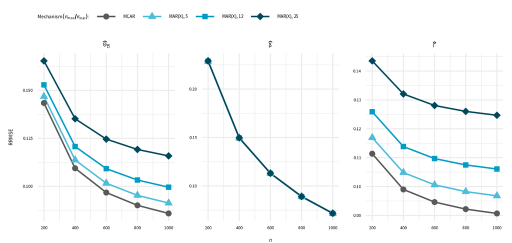

Figure 1

```r
miss$figures$figure_sens_missingness_paper_x
```

**MAR(XZ)**

**.**

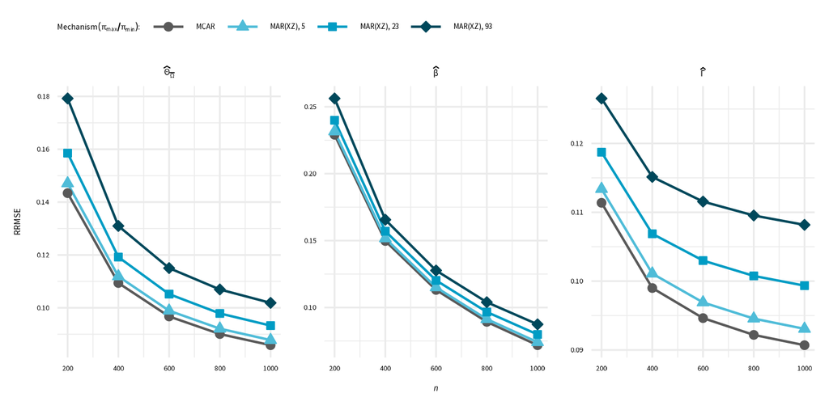

Figure 2

```r
miss$figures$figure_sens_missingness_paper_xz
```

## 2.3 other figures

**MAR(X), six panels**

**.**

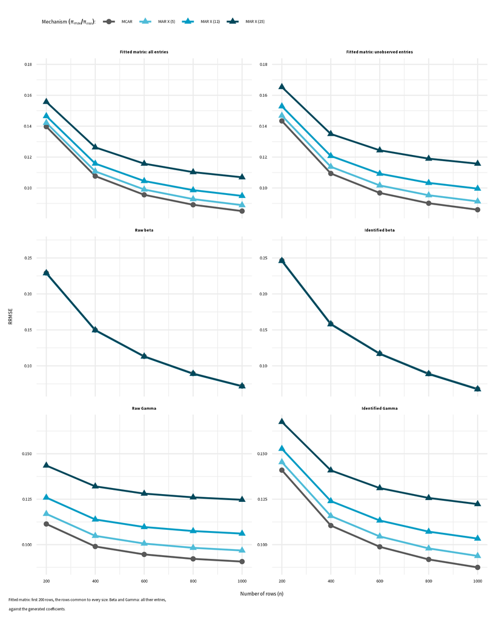

Figure 3

```r
miss$figures$figure_sens_missingness_x
```

**MAR(XZ), six panels**

**.**

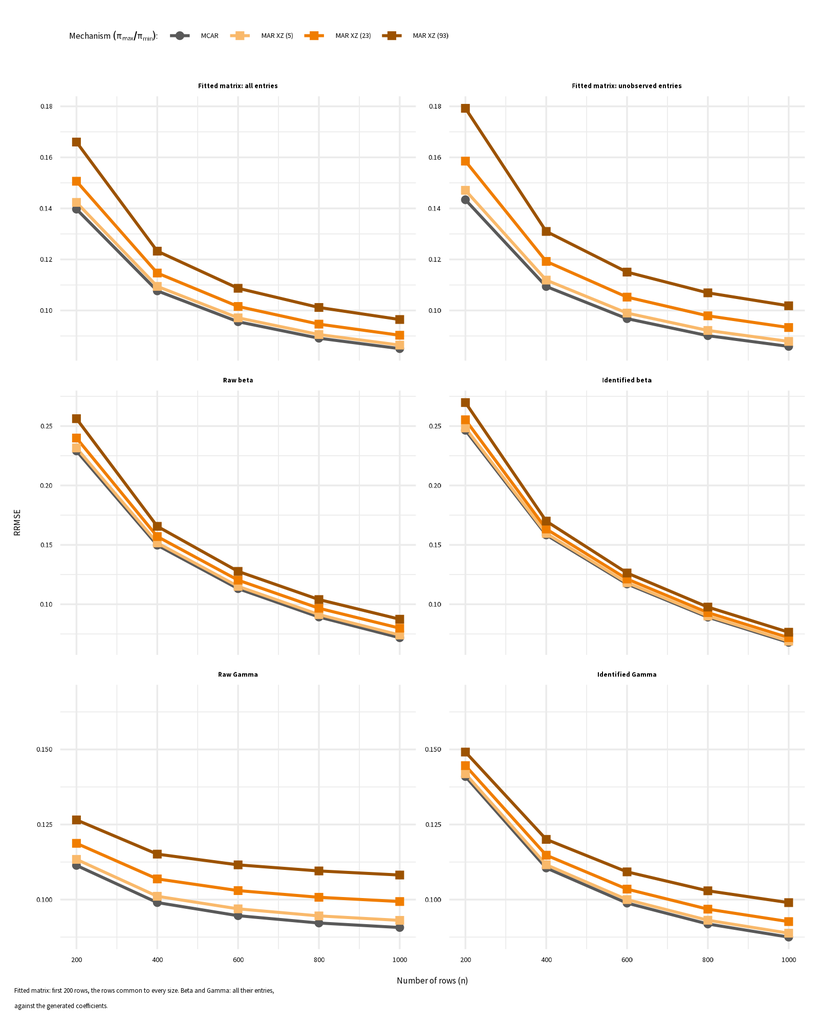

Figure 4

```r
miss$figures$figure_sens_missingness_xz
```

**All mechanisms, every error**

**.**

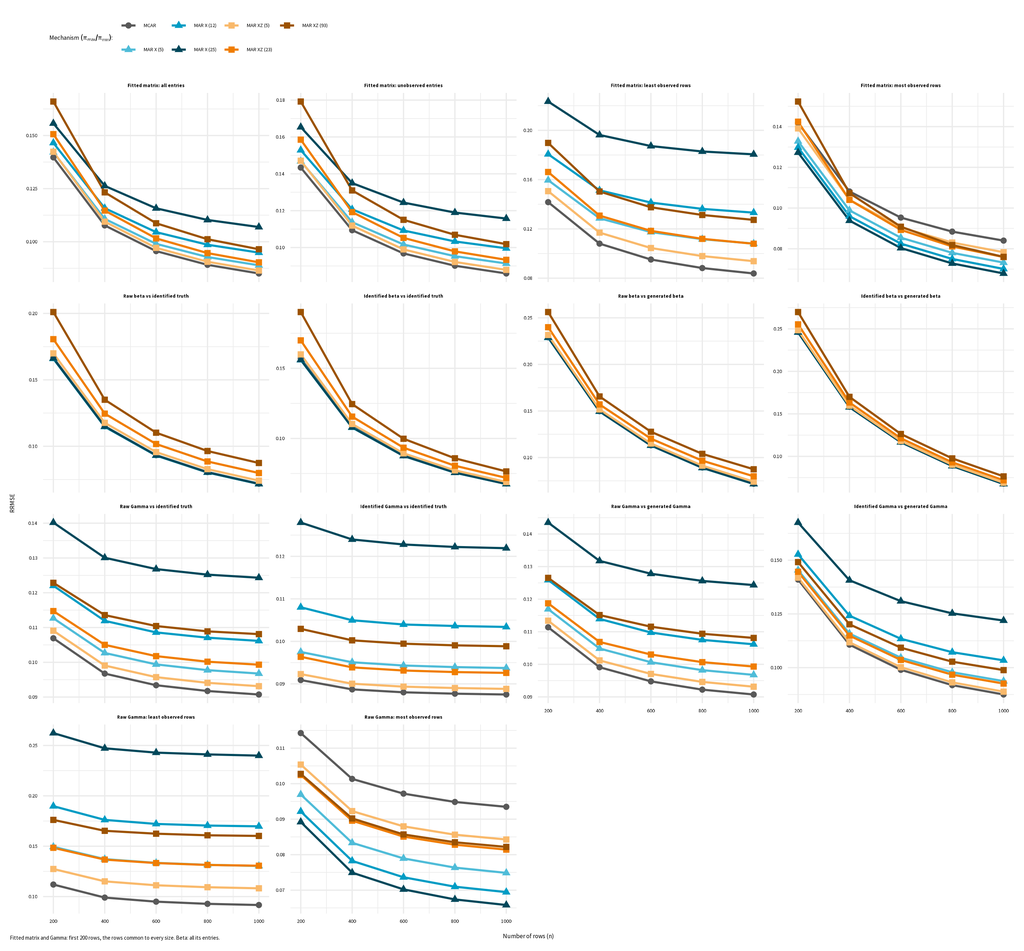

Figure 5

```r
miss$figures$figure_sens_missingness
```

# 3 Identified components

- $n=m=600$
- 50 simulated datasets ($X$, $Z$, $\beta$, $\Gamma$, $A$, $B$)
  - Noise, mask, and validation split random seed are regenerated 20 times in each.
  - two versions, one that satisfies C1-C3 and one that does not
- Scenario 1: SNR $\in\{0.5,1,3,10\}$ at 30% missing
- Scenario 2: $\{10,30,50,70,90\}$% missing at SNR 3.
- 6 random columns in $\beta$ and rows in $\Gamma$ are selected randomly and computed bias on them. (36 coefficients)

## 3.1 Tables

**Fits**

**.**

```r
ident$by_cell %>%
  summarise(
    #Fits = sum(fits), #Converged = mean(converged),
    Iterations = mean(n_iter), `$\\hat\\Theta$, all` = mean_sd(theta_all),
    `$\\hat\\Theta$, unobserved` = mean_sd(theta_unobs),
    #`$\\hat\\beta$ to $\\tilde\\beta$` = mean(beta_raw_id),
    #`$\\hat\\Gamma$ to $\\tilde\\Gamma$` = mean(gamma_raw_id),
    .groups = "drop"
  ) %>%
  mutate(Truth = truth, Cell = cell_label(scenario, level),
         .before = 1) %>%
  arrange(Truth) %>%
  select(-scenario, -truth, -level) %>%
  kable(digits = c(0, 0, 0, 2, 0, 4, 4, 3, 3))
```

Table 4: RRMSE of $\hat\Theta$

| Truth | Cell | Iterations | $\hat\Theta$, all | $\hat\Theta$, unobserved |
| --- | --- | --- | --- | --- |
| Truth satisfies (C1)–(C3) | SNR 0.5 | 8 | 0.3623 (0.0012) | 0.3668 (0.0014) |
| Truth satisfies (C1)–(C3) | SNR 1 | 6 | 0.1826 (0.0006) | 0.1850 (0.0007) |
| Truth satisfies (C1)–(C3) | SNR 3 | 5 | 0.0610 (0.0002) | 0.0618 (0.0002) |
| Truth satisfies (C1)–(C3) | SNR 10 | 4 | 0.0183 (0.0001) | 0.0185 (0.0001) |
| Truth satisfies (C1)–(C3) | 10% missing | 4 | 0.0536 (0.0002) | 0.0543 (0.0002) |
| Truth satisfies (C1)–(C3) | 30% missing | 5 | 0.0610 (0.0002) | 0.0618 (0.0002) |
| Truth satisfies (C1)–(C3) | 50% missing | 7 | 0.0727 (0.0002) | 0.0737 (0.0002) |
| Truth satisfies (C1)–(C3) | 70% missing | 12 | 0.0955 (0.0004) | 0.0967 (0.0004) |
| Truth satisfies (C1)–(C3) | 90% missing | 43 | 0.1832 (0.0008) | 0.1856 (0.0008) |
| Truth violates (C1)–(C3) | SNR 0.5 | 8 | 0.3623 (0.0012) | 0.3668 (0.0014) |
| Truth violates (C1)–(C3) | SNR 1 | 6 | 0.1826 (0.0006) | 0.1850 (0.0007) |
| Truth violates (C1)–(C3) | SNR 3 | 5 | 0.0610 (0.0002) | 0.0618 (0.0002) |
| Truth violates (C1)–(C3) | SNR 10 | 4 | 0.0183 (0.0001) | 0.0185 (0.0001) |
| Truth violates (C1)–(C3) | 10% missing | 4 | 0.0536 (0.0002) | 0.0543 (0.0002) |
| Truth violates (C1)–(C3) | 30% missing | 5 | 0.0610 (0.0002) | 0.0618 (0.0002) |
| Truth violates (C1)–(C3) | 50% missing | 7 | 0.0727 (0.0002) | 0.0737 (0.0002) |
| Truth violates (C1)–(C3) | 70% missing | 12 | 0.0955 (0.0004) | 0.0967 (0.0004) |
| Truth violates (C1)–(C3) | 90% missing | 44 | 0.1832 (0.0008) | 0.1856 (0.0008) |

**\(\beta\)**

**.**

```r
# Errors of one component by cell, mean (standard deviation) over the
# signals: the two estimates against the generating component and against
# its part of T(theta).
ident_table <- function(component, symbol) {
  columns <- paste0(component, c("_raw_gen", "_id_gen", "_raw_T", "_id_T"))
  headers <- c(
    sprintf("$\\hat\\%s$ vs $\\%s^\\star$", symbol, symbol),
    sprintf("$\\tilde\\%s$ vs $\\%s^\\star$", symbol, symbol),
    sprintf("$\\hat\\%s$ vs $T(\\Theta^\\star)$", symbol),
    sprintf("$\\tilde\\%s$ vs $T(\\Theta^\\star)$", symbol)
  )
  ident$by_cell %>%
    summarise(across(all_of(columns), mean_sd), .groups = "drop") %>%
    transmute(Truth = truth, Cell = cell_label(scenario, level),
              across(all_of(columns))) %>%
    arrange(Truth) %>%
    rename(all_of(setNames(columns, headers)))
}
kable(ident_table("beta", "beta"))
```

Table 5: RRMSE of $\beta$

| Truth | Cell | $\hat\beta$ vs $\beta^\star$ | $\tilde\beta$ vs $\beta^\star$ | $\hat\beta$ vs $T(\Theta^\star)$ | $\tilde\beta$ vs $T(\Theta^\star)$ |
| --- | --- | --- | --- | --- | --- |
| Truth satisfies (C1)–(C3) | SNR 0.5 | 0.3433 (0.0302) | 0.3433 (0.0302) | 0.3433 (0.0302) | 0.3433 (0.0302) |
| Truth satisfies (C1)–(C3) | SNR 1 | 0.1724 (0.0152) | 0.1717 (0.0151) | 0.1724 (0.0152) | 0.1717 (0.0151) |
| Truth satisfies (C1)–(C3) | SNR 3 | 0.0599 (0.0055) | 0.0572 (0.0050) | 0.0599 (0.0055) | 0.0572 (0.0050) |
| Truth satisfies (C1)–(C3) | SNR 10 | 0.0246 (0.0038) | 0.0172 (0.0015) | 0.0246 (0.0038) | 0.0172 (0.0015) |
| Truth satisfies (C1)–(C3) | 10% missing | 0.0521 (0.0047) | 0.0503 (0.0044) | 0.0521 (0.0047) | 0.0503 (0.0044) |
| Truth satisfies (C1)–(C3) | 30% missing | 0.0599 (0.0055) | 0.0572 (0.0050) | 0.0599 (0.0055) | 0.0572 (0.0050) |
| Truth satisfies (C1)–(C3) | 50% missing | 0.0714 (0.0065) | 0.0683 (0.0060) | 0.0714 (0.0065) | 0.0683 (0.0060) |
| Truth satisfies (C1)–(C3) | 70% missing | 0.0927 (0.0082) | 0.0896 (0.0077) | 0.0927 (0.0082) | 0.0896 (0.0077) |
| Truth satisfies (C1)–(C3) | 90% missing | 0.1741 (0.0155) | 0.1723 (0.0153) | 0.1741 (0.0155) | 0.1723 (0.0153) |
| Truth violates (C1)–(C3) | SNR 0.5 | 0.3612 (0.0330) | 0.3638 (0.0339) | 0.3424 (0.0295) | 0.3421 (0.0294) |
| Truth violates (C1)–(C3) | SNR 1 | 0.2046 (0.0212) | 0.2084 (0.0228) | 0.1725 (0.0150) | 0.1711 (0.0147) |
| Truth violates (C1)–(C3) | SNR 3 | 0.1247 (0.0189) | 0.1304 (0.0210) | 0.0617 (0.0061) | 0.0570 (0.0049) |
| Truth violates (C1)–(C3) | SNR 10 | 0.1120 (0.0195) | 0.1182 (0.0216) | 0.0292 (0.0055) | 0.0171 (0.0015) |
| Truth violates (C1)–(C3) | 10% missing | 0.1228 (0.0196) | 0.1275 (0.0211) | 0.0533 (0.0050) | 0.0501 (0.0043) |
| Truth violates (C1)–(C3) | 30% missing | 0.1247 (0.0189) | 0.1304 (0.0210) | 0.0617 (0.0061) | 0.0570 (0.0049) |
| Truth violates (C1)–(C3) | 50% missing | 0.1297 (0.0187) | 0.1357 (0.0210) | 0.0737 (0.0074) | 0.0680 (0.0059) |
| Truth violates (C1)–(C3) | 70% missing | 0.1415 (0.0185) | 0.1475 (0.0211) | 0.0949 (0.0090) | 0.0893 (0.0075) |
| Truth violates (C1)–(C3) | 90% missing | 0.2046 (0.0216) | 0.2090 (0.0239) | 0.1752 (0.0157) | 0.1717 (0.0149) |

**\(\Gamma\)**

**.**

```r
kable(ident_table("gamma", "Gamma"))
```

Table 6: RRMSE of $\Gamma$

| Truth | Cell | $\hat\Gamma$ vs $\Gamma^\star$ | $\tilde\Gamma$ vs $\Gamma^\star$ | $\hat\Gamma$ vs $T(\Theta^\star)$ | $\tilde\Gamma$ vs $T(\Theta^\star)$ |
| --- | --- | --- | --- | --- | --- |
| Truth satisfies (C1)–(C3) | SNR 0.5 | 0.3299 (0.0289) | 0.3293 (0.0289) | 0.3299 (0.0289) | 0.3293 (0.0289) |
| Truth satisfies (C1)–(C3) | SNR 1 | 0.1656 (0.0144) | 0.1647 (0.0144) | 0.1656 (0.0144) | 0.1647 (0.0144) |
| Truth satisfies (C1)–(C3) | SNR 3 | 0.0575 (0.0048) | 0.0549 (0.0048) | 0.0575 (0.0048) | 0.0549 (0.0048) |
| Truth satisfies (C1)–(C3) | SNR 10 | 0.0236 (0.0031) | 0.0165 (0.0014) | 0.0236 (0.0031) | 0.0165 (0.0014) |
| Truth satisfies (C1)–(C3) | 10% missing | 0.0499 (0.0043) | 0.0482 (0.0043) | 0.0499 (0.0043) | 0.0482 (0.0043) |
| Truth satisfies (C1)–(C3) | 30% missing | 0.0575 (0.0048) | 0.0549 (0.0048) | 0.0575 (0.0048) | 0.0549 (0.0048) |
| Truth satisfies (C1)–(C3) | 50% missing | 0.0686 (0.0058) | 0.0654 (0.0057) | 0.0686 (0.0058) | 0.0654 (0.0057) |
| Truth satisfies (C1)–(C3) | 70% missing | 0.0892 (0.0075) | 0.0860 (0.0074) | 0.0892 (0.0075) | 0.0860 (0.0074) |
| Truth satisfies (C1)–(C3) | 90% missing | 0.1675 (0.0139) | 0.1652 (0.0140) | 0.1675 (0.0139) | 0.1652 (0.0140) |
| Truth violates (C1)–(C3) | SNR 0.5 | 0.3460 (0.0309) | 0.3478 (0.0306) | 0.3296 (0.0284) | 0.3287 (0.0284) |
| Truth violates (C1)–(C3) | SNR 1 | 0.1950 (0.0193) | 0.1983 (0.0194) | 0.1660 (0.0141) | 0.1644 (0.0142) |
| Truth violates (C1)–(C3) | SNR 3 | 0.1169 (0.0182) | 0.1221 (0.0191) | 0.0594 (0.0047) | 0.0548 (0.0047) |
| Truth violates (C1)–(C3) | SNR 10 | 0.1041 (0.0193) | 0.1098 (0.0204) | 0.0280 (0.0041) | 0.0164 (0.0014) |
| Truth violates (C1)–(C3) | 10% missing | 0.1148 (0.0187) | 0.1191 (0.0194) | 0.0512 (0.0041) | 0.0481 (0.0042) |
| Truth violates (C1)–(C3) | 30% missing | 0.1169 (0.0182) | 0.1221 (0.0191) | 0.0594 (0.0047) | 0.0548 (0.0047) |
| Truth violates (C1)–(C3) | 50% missing | 0.1218 (0.0179) | 0.1272 (0.0188) | 0.0709 (0.0057) | 0.0653 (0.0057) |
| Truth violates (C1)–(C3) | 70% missing | 0.1340 (0.0175) | 0.1391 (0.0182) | 0.0915 (0.0073) | 0.0858 (0.0073) |
| Truth violates (C1)–(C3) | 90% missing | 0.1945 (0.0189) | 0.1982 (0.0190) | 0.1688 (0.0135) | 0.1649 (0.0138) |

## 3.2 Figures in the paper

**SNR varies**

**.**

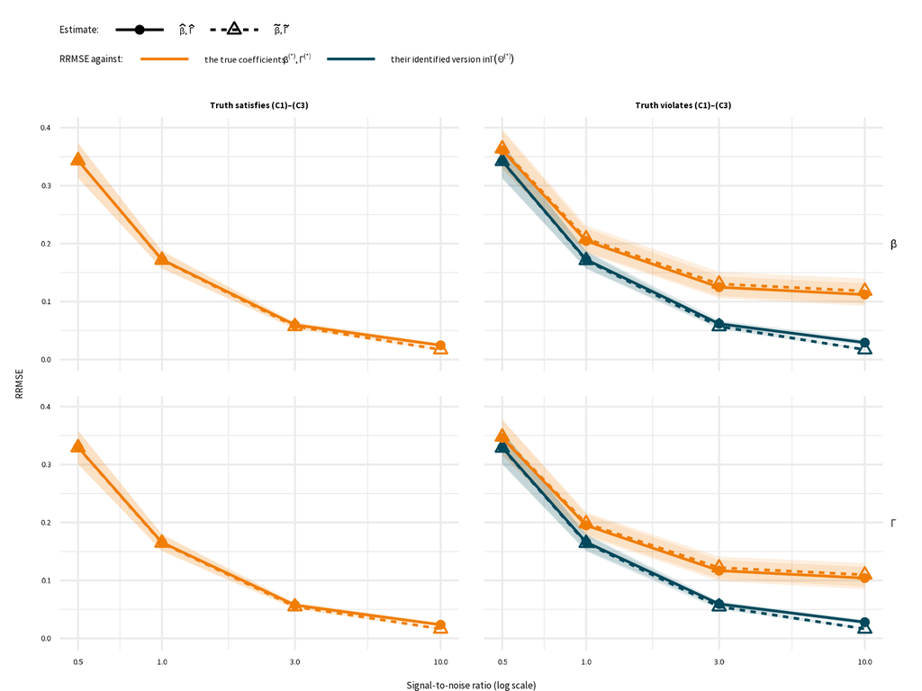

Figure 6: 30% missing

```r
ident$figures$figure_sens_ident_noise
```

**Missing rate varies**

**.**

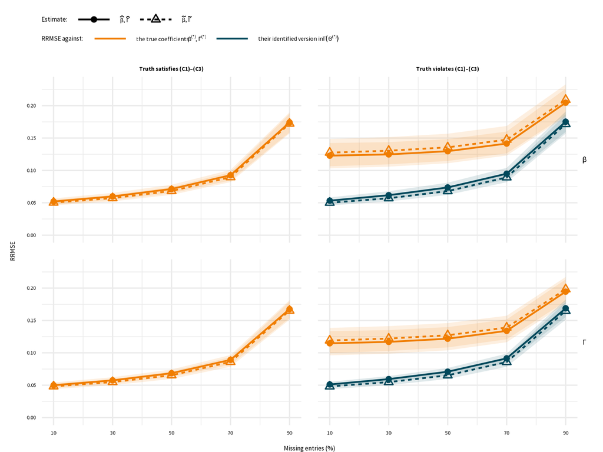

Figure 7: SNR 3

```r
ident$figures$figure_sens_ident_missing
```

**Individual coefficients**

**.**

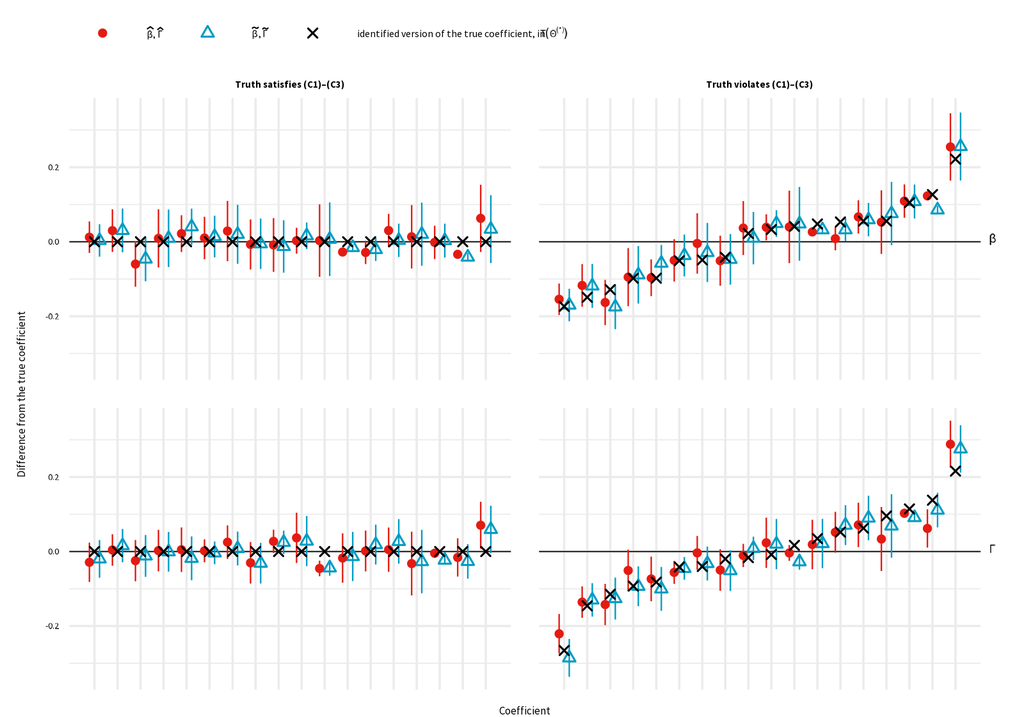

Figure 8: SNR 3 and 30% missing; bars are $\pm1$ standard deviation

```r
ident$figures$figure_sens_ident_coefs
```

## 3.3 other figure

**.**

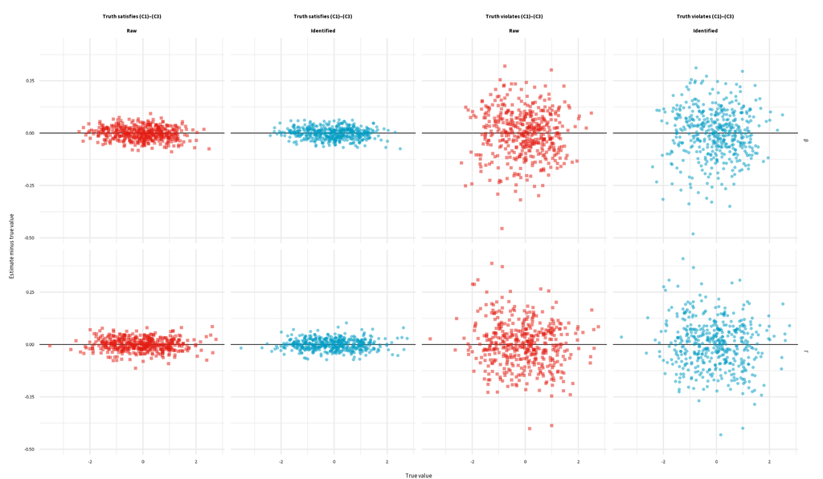

Figure 9: Individual coefficients at SNR 3 and 30% missing over replications

```r
ident$figures$figure_sens_ident_coefs_all
```

# 4 Identified components, sparse coefficients

- same design as before without the conditions and with half of the entries of $\beta$ and of $\Gamma$ set to zero at random.
- $\lambda_m,\lambda_\beta$ and $\lambda_\Gamma$ are tuned
- Negligible estimate is $|\text{estimate}|\le0.05$, for the individual coefficients.

## 4.1 Tables

**\(\hat\Theta\)**

**.**

```r
# Errors by cell, mean (standard deviation) over the signals. `columns`
# names the columns of the results by their headers.
sparse_table <- function(columns) {
  sparse$by_cell %>%
    summarise(across(all_of(unname(columns)), mean_sd), .groups = "drop") %>%
    mutate(Cell = cell_label(scenario, level), .before = 1) %>%
    select(-scenario, -level) %>%
    rename(all_of(columns))
}
kable(sparse_table(c(
  `$\\hat\\Theta$` = "theta_all",
  `$\\hat\\Theta$, no Lasso` = "theta_all_plain",
  `$\\hat\\Theta$, unobserved` = "theta_unobs"
)))
```

Table 7: RRMSE of $\hat\Theta$

| Cell | $\hat\Theta$ | $\hat\Theta$, no Lasso | $\hat\Theta$, unobserved |
| --- | --- | --- | --- |
| SNR 0.5 | 0.3400 (0.0015) | 0.3630 (0.0013) | 0.3437 (0.0017) |
| SNR 1 | 0.1743 (0.0006) | 0.1830 (0.0006) | 0.1763 (0.0007) |
| SNR 3 | 0.0587 (0.0002) | 0.0610 (0.0002) | 0.0594 (0.0002) |
| SNR 10 | 0.0177 (0.0001) | 0.0183 (0.0001) | 0.0179 (0.0001) |
| 10% missing | 0.0516 (0.0002) | 0.0536 (0.0002) | 0.0522 (0.0002) |
| 30% missing | 0.0587 (0.0002) | 0.0610 (0.0002) | 0.0594 (0.0002) |
| 50% missing | 0.0699 (0.0003) | 0.0728 (0.0002) | 0.0707 (0.0003) |
| 70% missing | 0.0915 (0.0004) | 0.0955 (0.0004) | 0.0926 (0.0004) |
| 90% missing | 0.1727 (0.0010) | 0.1834 (0.0008) | 0.1747 (0.0011) |

**\(\beta\)**

**.**

```r
kable(sparse_table(c(
  `$\\hat\\beta$` = "beta_raw_gen",
  `$\\hat\\beta$, no Lasso` = "beta_plain_gen",
  `$\\tilde\\beta$` = "beta_id_gen"
)))
```

Table 8: RRMSE for $\beta$

| Cell | $\hat\beta$ | $\hat\beta$, no Lasso | $\tilde\beta$ |
| --- | --- | --- | --- |
| SNR 0.5 | 0.3569 (0.0285) | 0.4432 (0.0425) | 0.3815 (0.0333) |
| SNR 1 | 0.1884 (0.0166) | 0.2575 (0.0280) | 0.2413 (0.0279) |
| SNR 3 | 0.0650 (0.0060) | 0.1664 (0.0254) | 0.1699 (0.0277) |
| SNR 10 | 0.0208 (0.0022) | 0.1525 (0.0260) | 0.1592 (0.0284) |
| 10% missing | 0.0573 (0.0052) | 0.1642 (0.0261) | 0.1674 (0.0279) |
| 30% missing | 0.0650 (0.0060) | 0.1664 (0.0254) | 0.1699 (0.0277) |
| 50% missing | 0.0779 (0.0072) | 0.1719 (0.0251) | 0.1744 (0.0276) |
| 70% missing | 0.1024 (0.0089) | 0.1850 (0.0250) | 0.1847 (0.0275) |
| 90% missing | 0.1902 (0.0170) | 0.2576 (0.0286) | 0.2405 (0.0288) |

**\(\Gamma\)**

**.**

```r
kable(sparse_table(c(
  `$\\hat\\Gamma$` = "gamma_raw_gen",
  `$\\hat\\Gamma$, no Lasso` = "gamma_plain_gen",
  `$\\tilde\\Gamma$` = "gamma_id_gen"
)))
```

Table 9: RRMSE of $\Gamma$

| Cell | $\hat\Gamma$ | $\hat\Gamma$, no Lasso | $\tilde\Gamma$ |
| --- | --- | --- | --- |
| SNR 0.5 | 0.3470 (0.0298) | 0.4272 (0.0423) | 0.3693 (0.0329) |
| SNR 1 | 0.1819 (0.0174) | 0.2466 (0.0274) | 0.2305 (0.0264) |
| SNR 3 | 0.0626 (0.0062) | 0.1564 (0.0256) | 0.1593 (0.0268) |
| SNR 10 | 0.0198 (0.0021) | 0.1422 (0.0266) | 0.1483 (0.0276) |
| 10% missing | 0.0550 (0.0054) | 0.1539 (0.0260) | 0.1567 (0.0269) |
| 30% missing | 0.0626 (0.0062) | 0.1564 (0.0256) | 0.1593 (0.0268) |
| 50% missing | 0.0746 (0.0074) | 0.1619 (0.0255) | 0.1638 (0.0264) |
| 70% missing | 0.0980 (0.0095) | 0.1757 (0.0253) | 0.1744 (0.0259) |
| 90% missing | 0.1823 (0.0168) | 0.2460 (0.0270) | 0.2283 (0.0254) |

## 4.2 Figures in the paper

**SNR changes**

**.**

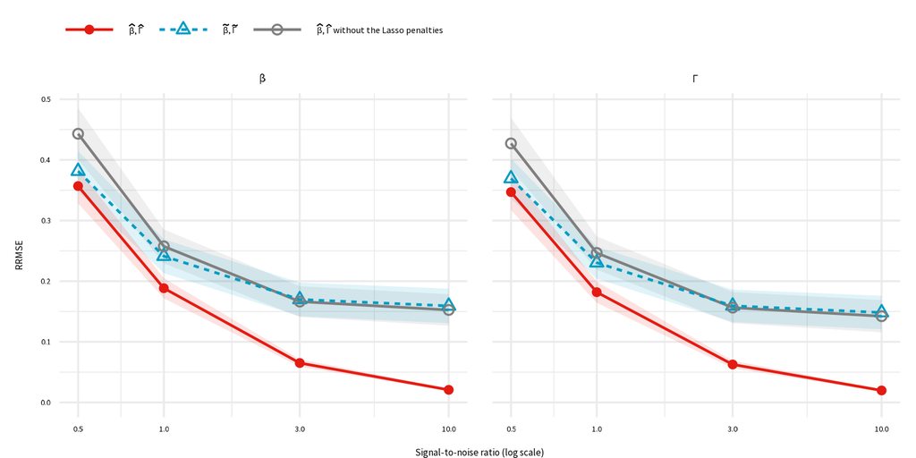

Figure 10: 30% missing

```r
sparse$figures$figure_sens_ident_sparse_noise
```

**Missing rate changes**

**.**

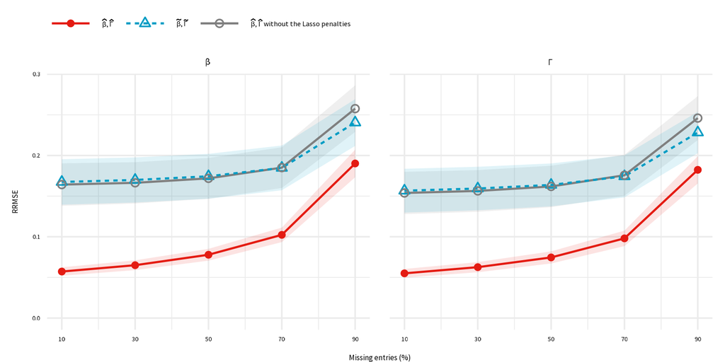

Figure 11: SNR 3

```r
sparse$figures$figure_sens_ident_sparse_missing
```

**Sparse estimates / snr changes**

**.**

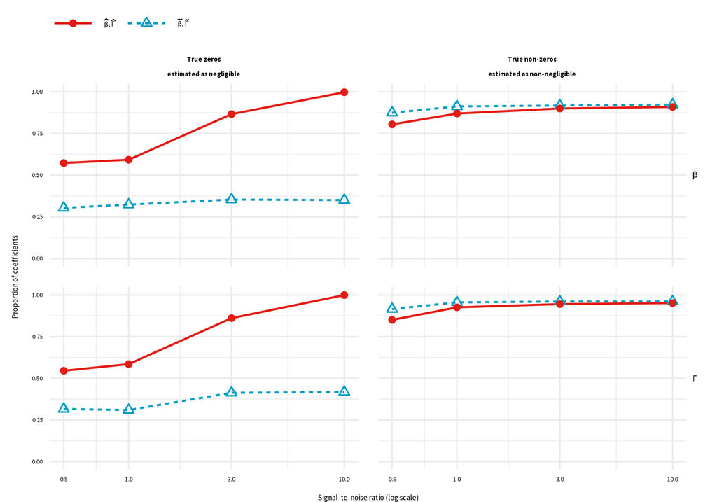

Figure 12

```r
sparse$figures$figure_sens_ident_sparse_zeros_noise
```

## 4.3 other figures

**sparse estimates / missing rate changes**

**.**

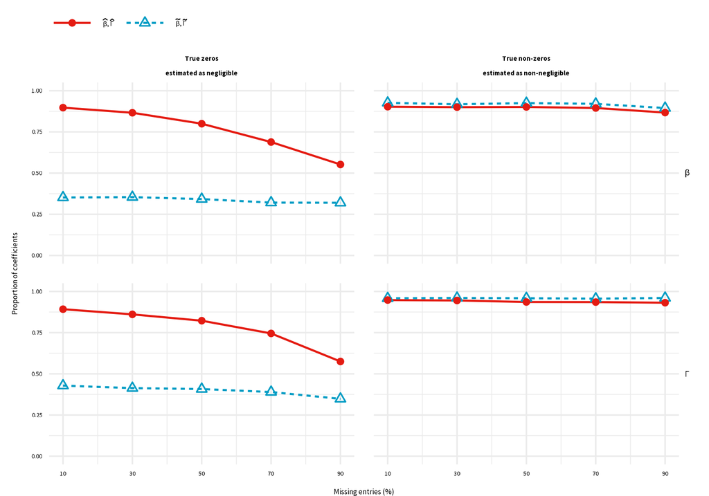

Figure 13

```r
sparse$figures$figure_sens_ident_sparse_zeros_missing
```

**Individual coefficients on one dataset**

**.**

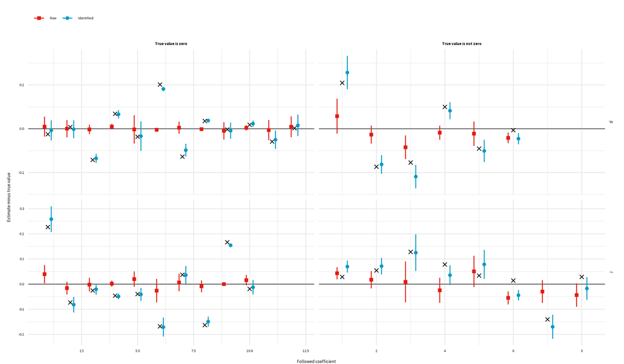

Figure 14: SNR 3 and 30% missing

```r
sparse$figures$figure_sens_ident_sparse_coefs
```

**Individual coefficients**

**.**

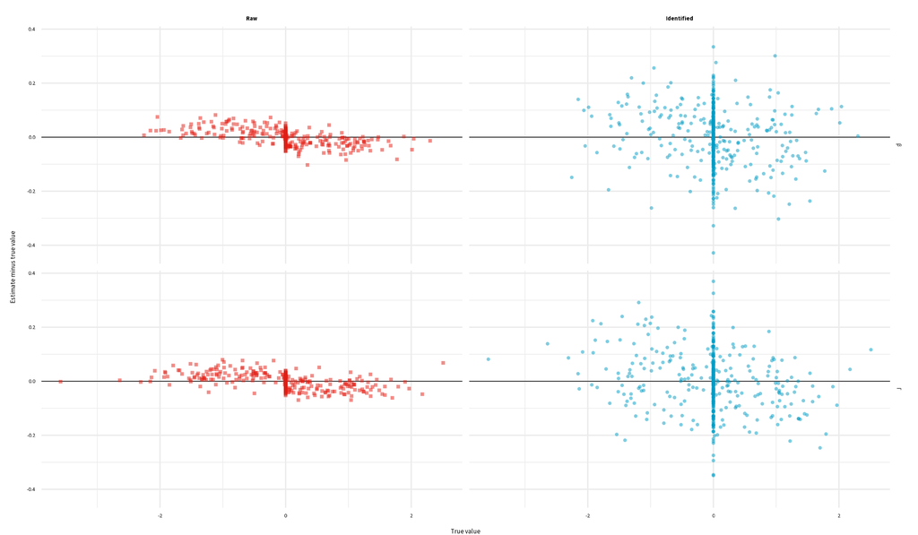

Figure 15: SNR 3 and 30% missing

```r
sparse$figures$figure_sens_ident_sparse_coefs_all
```

# 5 Initialization

- Five $600\times600$ data sets
- 70% missing (MCAR),
- SNR 3.
- hyperparameters are tuned and fixed
- 12 different warm starts
  - the default (`ls_initial = TRUE`)
  - zero matrices (`ls_initial = FALSE`)
  - 10 random matrices

## 5.1 Tables

**Iterations**

**.**

```r
old$init_rows %>%
  group_by(Tolerance = level, Start = kind) %>%
  summarise(Fits = n(), `Median iterations` = median(n_iter),
            .groups = "drop") %>%
  mutate(Tolerance = if_else(Tolerance == "short", "1e-6", "1e-12")) %>%
  kable()
```

| Tolerance | Start | Fits | Median iterations |
| --- | --- | --- | --- |
| 1e-6 | Default | 5 | 88.0 |
| 1e-6 | Zero | 5 | 350.0 |
| 1e-6 | Random | 50 | 1916.5 |
| 1e-12 | Default | 5 | 2468.0 |
| 1e-12 | Zero | 5 | 4047.0 |
| 1e-12 | Random | 50 | 6556.5 |

**Figure**

**.**

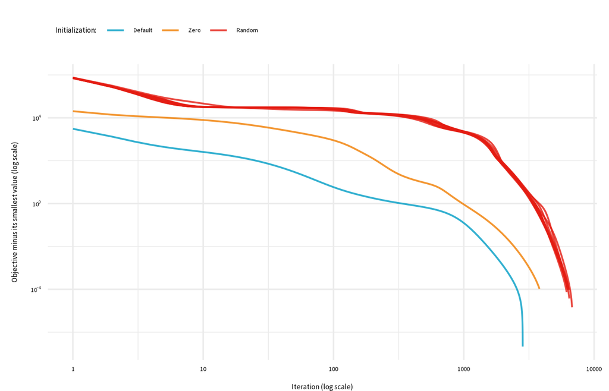

```r
old$figures$figure_sens_init
```

**Sources of variability**

**.**

```r
everything <- old$missing_rows %>% filter(mar_strength == 0)
old$sources_rows %>%
  group_by(source, seed) %>%
  summarise(mean = mean(rrmse_unobs), variance = var(rrmse_unobs),
            draws = n(), .groups = "drop") %>%
  group_by(Redrawn = as.character(source)) %>%
  summarise(`Data sets` = n(), `Draws per data set` = first(draws),
            Mean = mean(mean), `Standard deviation` = sqrt(mean(variance)),
            .groups = "drop") %>%
  arrange(`Standard deviation`) %>%
  select(-`Draws per data set`) %>%
  # bind_rows(data.frame(
  #   Redrawn = "Everything",
  #   `Data sets` = nrow(everything),
  #   `Draws per data set` = 1, Mean = mean(everything$rrmse_unobs),
  #   `Standard deviation` = sd(everything$rrmse_unobs), check.names = FALSE
  # )) %>%
  kable(digits = 4)
```

Table 11: Test RRMSE of $\hat\Theta$

| Redrawn | Data sets | Mean | Standard deviation |
| --- | --- | --- | --- |
| Validation split | 5 | 0.1049 | 2e-04 |
| Initial values | 5 | 0.1054 | 3e-04 |
| Observed entries | 5 | 0.1045 | 7e-04 |
| Noise | 5 | 0.1046 | 7e-04 |

**Figure**

**.**

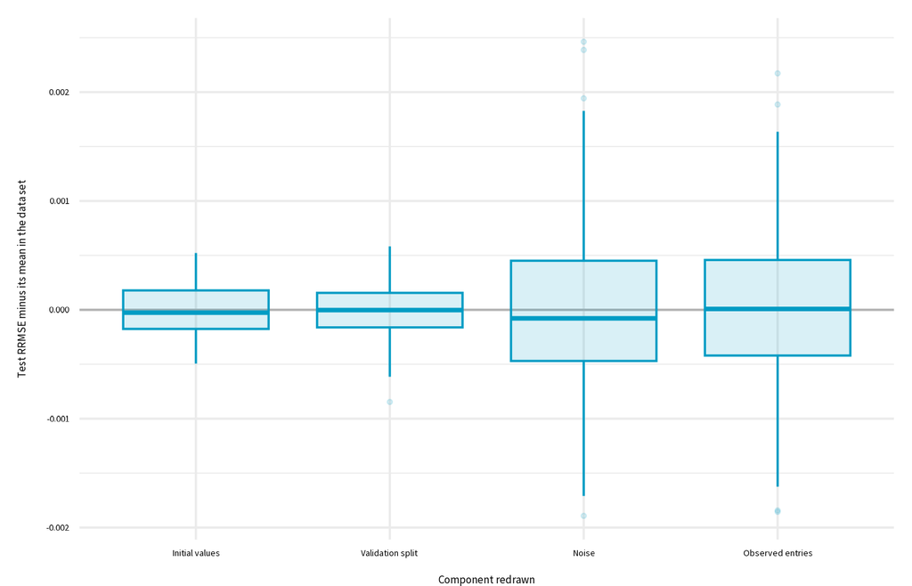

Figure 17: Test RRMSE minus its mean in the data set.

```r
old$figures$figure_sens_sources
```